# Stars 2

Walter Humberto Subiza Pina

12/5/2020

### Manipulação de objetos stars raster e vetoriales

Começamos carregando novamente a imagem de exemplo da biblioteca **stars**. O arquivo é uma imagem Landsat 7 ETM formato Geotiff, com 6 bandas, azul, verde, vermelho (BGR) e 3 mais de infravermelho próximo.

```r
library(stars)
```

### 1. Lendo o raster

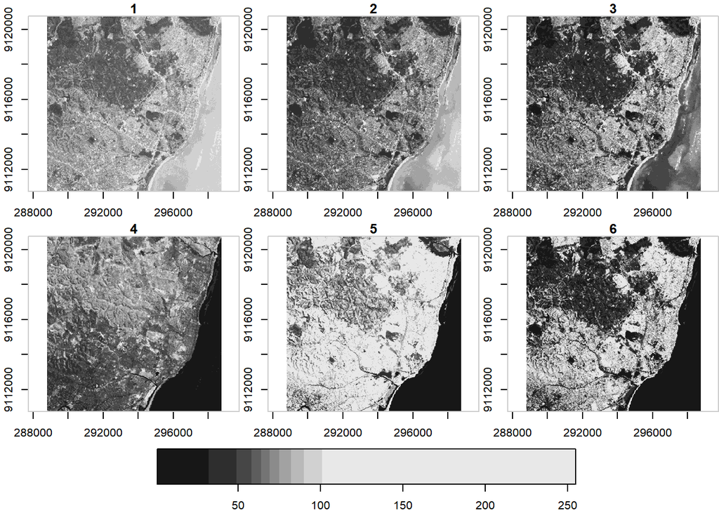

```r
tif = system.file("tif/L7_ETMs.tif", package = "stars")# creação do caminho do arquivo como objeto texto

img = read_stars(tif) # leitura do arquivo

plot(img, axes = T) # visualição das 6 bandas
```

É um objeto de 3 dimensões, *x*, *y*, *band* em formato de lista. Se olhamos o objeto *img* na janela de ambiente do *RStudio*, vemos um vetor numérico com o tamanho de cada dimensão [1:349, 1:352, 1:6] e os valores na sequencia.

### 2. Conversão de dimensão em atributos e atributos em dimensão

O objeto lido tem na sua terceira dimensão *band* uma lista com as bandas 1 a 6. É possível passar as bandas para atributos e eliminar a dimensão correspondente.

Desta forma, o novo objeto que será criado terá somente as dimensões espaciales de *x* e *y* e 6 novos atributos. A função que será usada é *split()*, que divide os dados indicados no primeiro argumento, em grupos definidos pelo segundo argumento colocado.

```r
# separação da imagem pela dimensão bandas
(img.sep = split(img, "band"))
```

```
## stars object with 2 dimensions and 6 attributes
## attribute(s):
##       X1               X2               X3               X4
##  Min.   : 47.00   Min.   : 32.00   Min.   : 21.00   Min.   :  9.00
##  1st Qu.: 67.00   1st Qu.: 55.00   1st Qu.: 49.00   1st Qu.: 52.00
##  Median : 78.00   Median : 66.00   Median : 63.00   Median : 63.00
##  Mean   : 79.15   Mean   : 67.57   Mean   : 64.36   Mean   : 59.24
##  3rd Qu.: 89.00   3rd Qu.: 79.00   3rd Qu.: 77.00   3rd Qu.: 75.00
##  Max.   :255.00   Max.   :255.00   Max.   :255.00   Max.   :255.00
##       X5               X6
##  Min.   :  1.00   Min.   :  1.00
##  1st Qu.: 63.00   1st Qu.: 32.00
##  Median : 89.00   Median : 60.00
##  Mean   : 83.18   Mean   : 59.98
##  3rd Qu.:112.00   3rd Qu.: 88.00
##  Max.   :255.00   Max.   :255.00
## dimension(s):
##   from  to  offset delta                       refsys point values
## x    1 349  288776  28.5 UTM Zone 25, Southern Hem... FALSE   NULL [x]
## y    1 352 9120761 -28.5 UTM Zone 25, Southern Hem... FALSE   NULL [y]
```

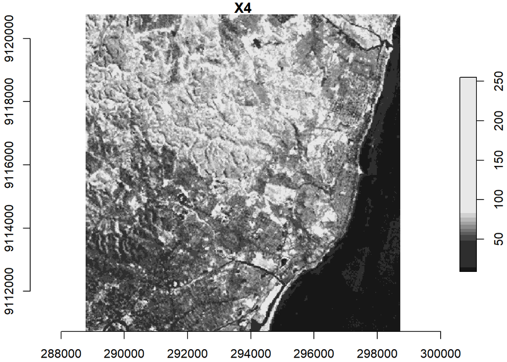

```r
# visualização do atributo X4, anterior banda 4
plot(img.sep["X4"], axes = T)
```

O objeto é da classe “Large stars” com 2 dimensões e 6 atributos de X1:X6, os valores encontram-se separados por atributo.

Fazer o caminho contrário também é simples, o seja temos um objeto com duas dimensões e 6 atributos e vamos colocar os atributos numa única dimensão, a função *merge()* realiza a tarefa.

Convertendo todos os atributos num única dimensão.

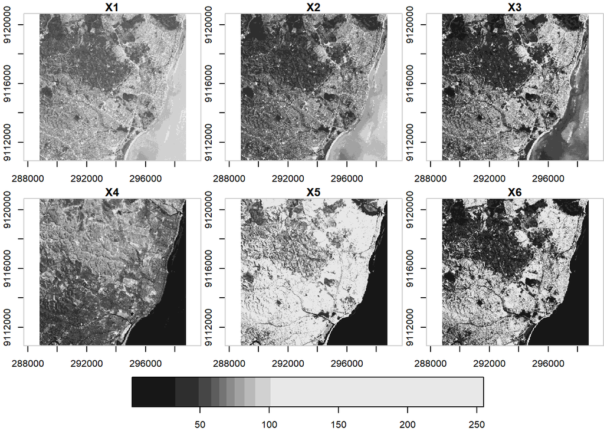

```r
img2 <-merge(img.sep)

plot(img2, axes = T)
```

Voltamos ao formato inicial, mas nesse processo perderom-se alguns nomes na nova dimensão criada. Podemos restaurar os nomes iniciais ou colocar novos como no exemplo siguiente.

```r
img2 <- merge(img.sep)       %>%
        setNames(names(img)) %>%
        st_set_dimensions(3,        # definindo os nomes das bandas na dimensão 3
                          values = paste0("banda ", 1:6)) %>%
                          st_set_dimensions(names = c("lon", "lat", "banda")) # nomes das dimensões

img2
```

```
## stars object with 3 dimensions and 1 attribute
## attribute(s):
##   L7_ETMs.tif
##  Min.   :  1.00
##  1st Qu.: 54.00
##  Median : 69.00
##  Mean   : 68.91
##  3rd Qu.: 86.00
##  Max.   :255.00
## dimension(s):
##       from  to  offset delta                       refsys point
## lon      1 349  288776  28.5 UTM Zone 25, Southern Hem... FALSE
## lat      1 352 9120761 -28.5 UTM Zone 25, Southern Hem... FALSE
## banda    1   6      NA    NA                           NA    NA
##                    values
## lon                  NULL [x]
## lat                  NULL [y]
## banda banda 1,...,banda 6
```

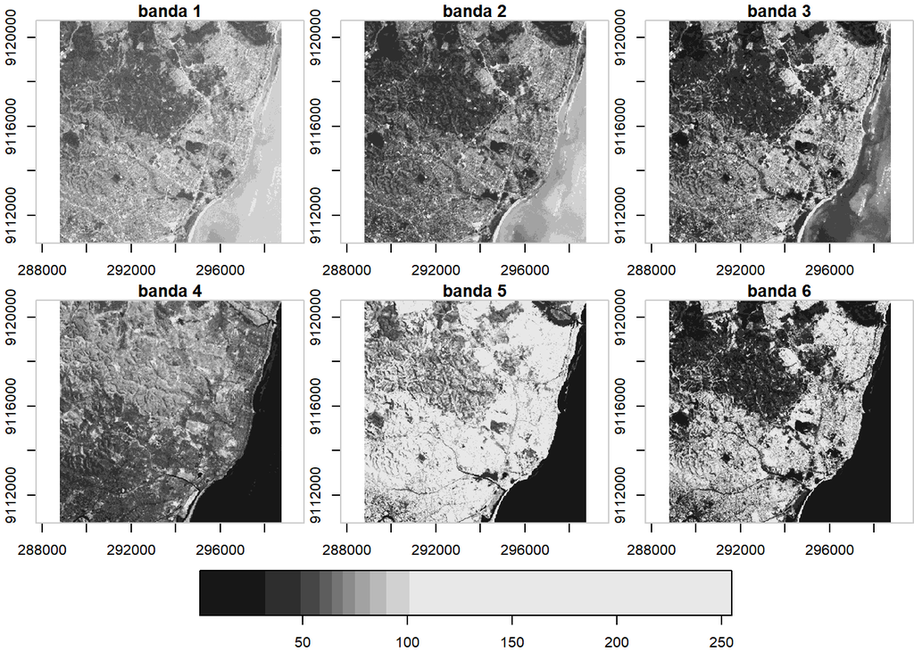

```r
plot(img2, axes = T)
```

### 3. Extração de valores usando objetos vectoriales

Carregamos no ambiente o polígono do município de Olinda, Brasil, usado no documento anterior.

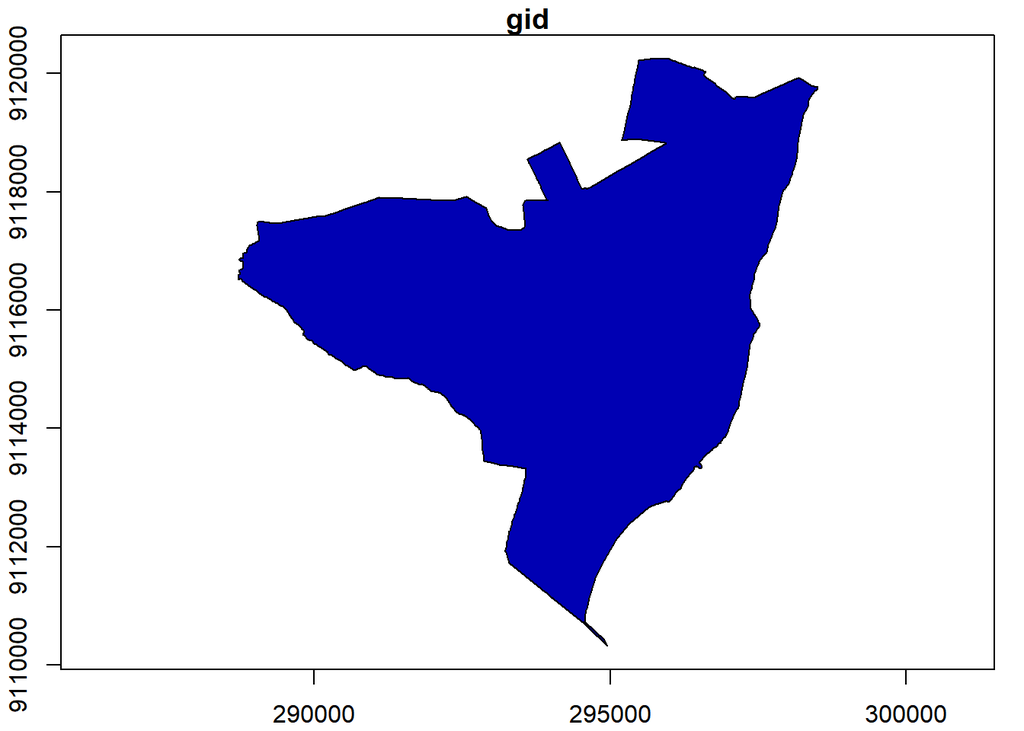

```r
olinda <- read_sf("C:/Users/Walter Pina/Documents/Github/spatial_stars/datos/olinda.shp") # leitura do arquivo, o caminho debe ser atualizado com os dados da real localização no seu computador

plot(olinda["gid"], axes = T)
```

O passo a passo para extrair valores da imagem usando o polígono é:

1. Verificar se ambos os objetos estão no mesmo sistema de referencia.

```r
st_crs(olinda)
```

```
## Coordinate Reference System:
##   User input: WGS 84 / UTM zone 25S
##   wkt:
## PROJCRS["WGS 84 / UTM zone 25S",
##     BASEGEOGCRS["WGS 84",
##         DATUM["World Geodetic System 1984",
##             ELLIPSOID["WGS 84",6378137,298.257223563,
##                 LENGTHUNIT["metre",1]]],
##         PRIMEM["Greenwich",0,
##             ANGLEUNIT["degree",0.0174532925199433]],
##         ID["EPSG",4326]],
##     CONVERSION["UTM zone 25S",
##         METHOD["Transverse Mercator",
##             ID["EPSG",9807]],
##         PARAMETER["Latitude of natural origin",0,
##             ANGLEUNIT["Degree",0.0174532925199433],
##             ID["EPSG",8801]],
##         PARAMETER["Longitude of natural origin",-33,
##             ANGLEUNIT["Degree",0.0174532925199433],
##             ID["EPSG",8802]],
##         PARAMETER["Scale factor at natural origin",0.9996,
##             SCALEUNIT["unity",1],
##             ID["EPSG",8805]],
##         PARAMETER["False easting",500000,
##             LENGTHUNIT["metre",1],
##             ID["EPSG",8806]],
##         PARAMETER["False northing",10000000,
##             LENGTHUNIT["metre",1],
##             ID["EPSG",8807]]],
##     CS[Cartesian,2],
##         AXIS["(E)",east,
##             ORDER[1],
##             LENGTHUNIT["metre",1]],
##         AXIS["(N)",north,
##             ORDER[2],
##             LENGTHUNIT["metre",1]],
##     ID["EPSG",32725]]
```

```r
st_crs(img)
```

```
## Coordinate Reference System:
##   User input: UTM Zone 25, Southern Hemisphere
##   wkt:
## BOUNDCRS[
##     SOURCECRS[
##         PROJCRS["UTM Zone 25, Southern Hemisphere",
##             BASEGEOGCRS["GRS 1980(IUGG, 1980)",
##                 DATUM["unknown",
##                     ELLIPSOID["GRS80",6378137,298.257222101,
##                         LENGTHUNIT["metre",1,
##                             ID["EPSG",9001]]]],
##                 PRIMEM["Greenwich",0,
##                     ANGLEUNIT["degree",0.0174532925199433,
##                         ID["EPSG",9122]]]],
##             CONVERSION["Transverse Mercator",
##                 METHOD["Transverse Mercator",
##                     ID["EPSG",9807]],
##                 PARAMETER["Latitude of natural origin",0,
##                     ANGLEUNIT["degree",0.0174532925199433],
##                     ID["EPSG",8801]],
##                 PARAMETER["Longitude of natural origin",-33,
##                     ANGLEUNIT["degree",0.0174532925199433],
##                     ID["EPSG",8802]],
##                 PARAMETER["Scale factor at natural origin",0.9996,
##                     SCALEUNIT["unity",1],
##                     ID["EPSG",8805]],
##                 PARAMETER["False easting",500000,
##                     LENGTHUNIT["metre",1],
##                     ID["EPSG",8806]],
##                 PARAMETER["False northing",10000000,
##                     LENGTHUNIT["metre",1],
##                     ID["EPSG",8807]]],
##             CS[Cartesian,2],
##                 AXIS["easting",east,
##                     ORDER[1],
##                     LENGTHUNIT["metre",1,
##                         ID["EPSG",9001]]],
##                 AXIS["northing",north,
##                     ORDER[2],
##                     LENGTHUNIT["metre",1,
```

[output cut: 22 more lines]

```
##             ID["EPSG",9606]],
##         PARAMETER["X-axis translation",0,
##             ID["EPSG",8605]],
##         PARAMETER["Y-axis translation",0,
##             ID["EPSG",8606]],
##         PARAMETER["Z-axis translation",0,
##             ID["EPSG",8607]],
##         PARAMETER["X-axis rotation",0,
##             ID["EPSG",8608]],
##         PARAMETER["Y-axis rotation",0,
##             ID["EPSG",8609]],
##         PARAMETER["Z-axis rotation",0,
##             ID["EPSG",8610]],
##         PARAMETER["Scale difference",1,
##             ID["EPSG",8611]]]]
```

Dos resultados verificamos que estão em diferentes sistemas, sendo que apesar dos dois estarem em sistema UTM e na mesma zona 25S, os elipsóides no coincidem, ou seja:

| objeto | CRS | Elipsóide |
| --- | --- | --- |
| olinda | WGS 84 / UTM zone 25S | ELLIPSOID[“WGS 84”,6378137,298.257223563 |
| img | UTM Zone 25, Southern Hemisphere | ELLIPSOID[“GRS80”,6378137,298.257222101 |

```r
img <- st_transform(img, st_crs(olinda))
```

3. Com os dois objetos no mesmo sistema de referencia, será cortada a imagem nas bandas 1 a 3 (BGR), usando o polígono do municipio.

O corte será feito usando paréntesis reto, como vimos no documento 1 desta série.

```r
img_corte1 <- img[olinda][, , , 1:3]
```

Visualizar a imagem cortada na primera banda e o polígono de corte.

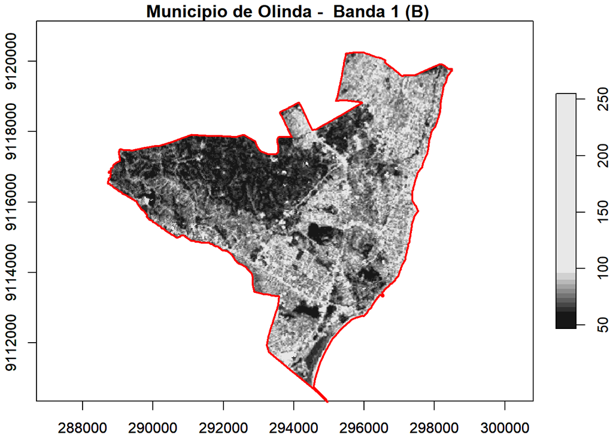

```r
plot(img_corte1[, , , 1],
     reset = FALSE,
     axes  = T,
     main  = " Municipio de Olinda -  Banda 1 (B)")

plot(olinda,
     col    = NA,
     border = 'red',
     add    = TRUE,
     lwd    = 2)
```

E todas as bandas cortadas…

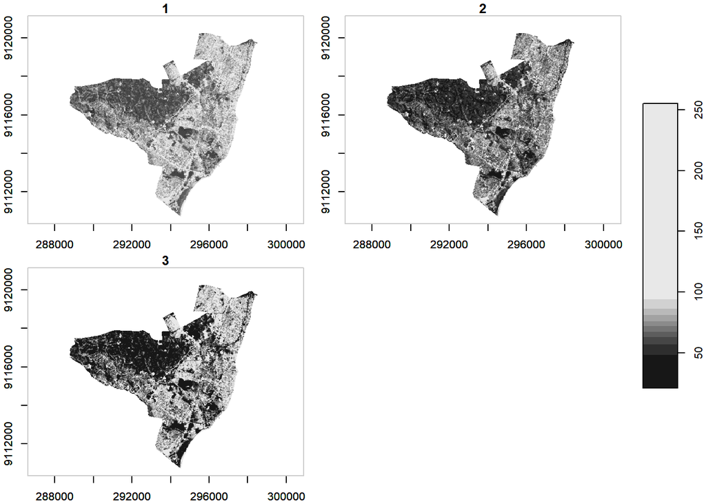

```r
plot(img_corte1, axes = T)
```

Outra forma de cortar (clip) uma imagen, é criando dentro do próprio ambiente *R* um objeto vetorial de corte. Começamos com o objeto mais simples, que é um círculo criado entorno dum ponto determinado.

1. Creação de um buffer de 2 km com centro no ponto (291500, 9117500), definição do sistema de referencia igual ao sistema da imagen a cortar.
2. Corte da imagem com o círculo de 2 km
3. Visualização

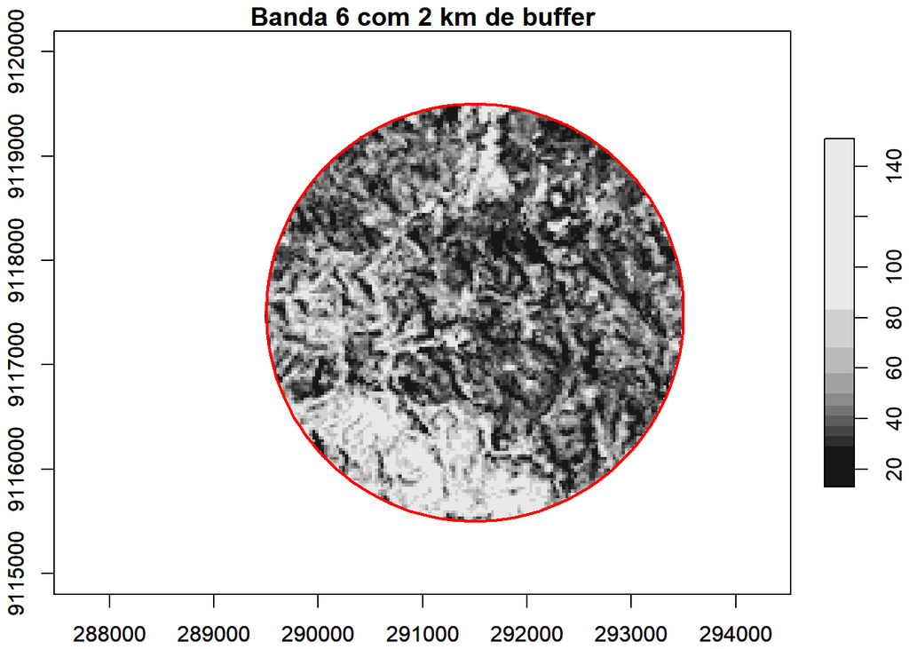

```r
# 1 Criação do círculo e definição do sistema de referencia
circulo = st_sfc(st_buffer( st_point(c(291500, 9117500)), 2000),
                 crs = st_crs(img))
# 2 corte
img_cir <- img[circulo][, , , 6]

# 3 visualização
plot(img_cir,
     axes  = T,
     reset = FALSE,
     main  = "Banda 6 com 2 km de buffer",
     ylim  = c(9115000, 9120000),
     xlim  = c(288000, 294000))

plot(circulo,
     col    = NA,
     border = 'red',
     add    = TRUE,
     lwd    = 2)
```

Também podemos usar um objeto polígono, para simplificar faremos um polígono quadrado de 3 km de lado.

1. Criação do polígono de 3 km x 3 km
2. Transformar a geometria em polígono
3. Definir o sistema de referencia, igual ao da imagem a cortar e transformar o objeto tipo sfg (geometria) em sfc (lista de geometria).
4. Visualizar o polígono
5. Cortar a imagem nas 3 bandas visíveis, usando o polígono. As bandas podem determinar-se específicamente também.
6. Visualizar

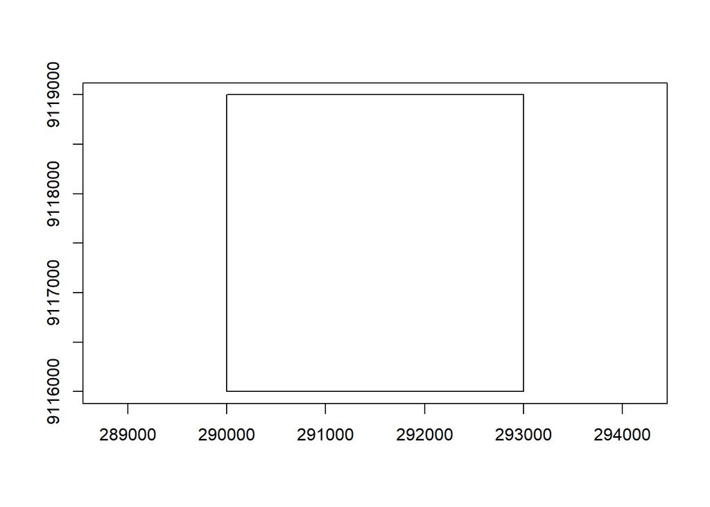

```r
# 1
pt1 = st_point(c(290000, 9119000))
pt2 = st_point(c(293000, 9119000))
pt3 = st_point(c(293000, 9116000))
pt4 = st_point(c(290000, 9116000))
pt5 = st_point(c(290000, 9119000)) # ponto de fechamenot, idéntico ao pt1
# 2
pol <-st_polygon(list(rbind(pt1, pt2, pt3, pt4, pt5)))
# 3
pol <- st_sfc(pol, crs = st_crs(img))
# 4
plot(pol, axes=T)
```

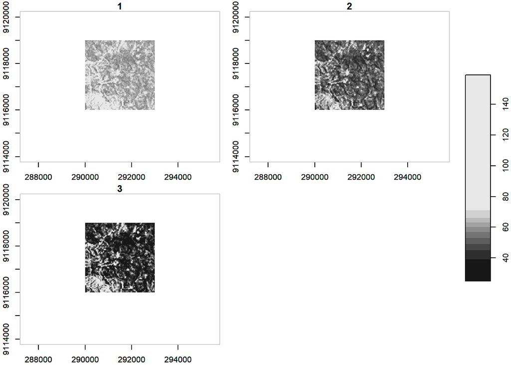

```r
# 5
img_corte2 <- img[pol][, , , 1:3]
# 6
plot( img[pol][, , , 1:3],
      axes = T,
      xlim = c(289000, 294000),
      ylim = c(9114000, 9120000))
```

### 4. Outras ferramentas de extração de datos

Extração usando a função *st_crop()* da biblioteca **sf**. Foi colocado no seguinte fragmento de código duos formas diferentes, usando o polígono já definido anteriormente ou estabelecendo os límites do corte en forma explícita com um vetor numérico. Esta função só pode ser usada com formas retangulares.

```r
p <- st_crop(img[, , , 1:3], pol)
```

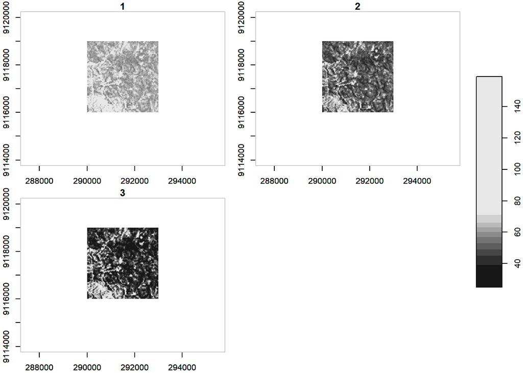

```r
# o polígono também pode ser determinado com xmin, ymin, xmax, ymax da forma:
# p <- st_crop(img, c(290000, 9116000, 293000, 9119000))
#
plot(p, axes = T,
      xlim = c(289000, 294000),
      ylim = c(9114000, 9120000))
```

A función *cut* corta a imagem, classificando os valores em categorias, por exemplo, no fragmento de código a seguir vamos classificar cada banda em tres categorias: valores de pixel entre 0 e 50, entre 50 e 100, e finalmente entre 100 e 255. Esta função pode ser útil em caso de desejar-se extrair ou eliminar valores determinados do atributo.

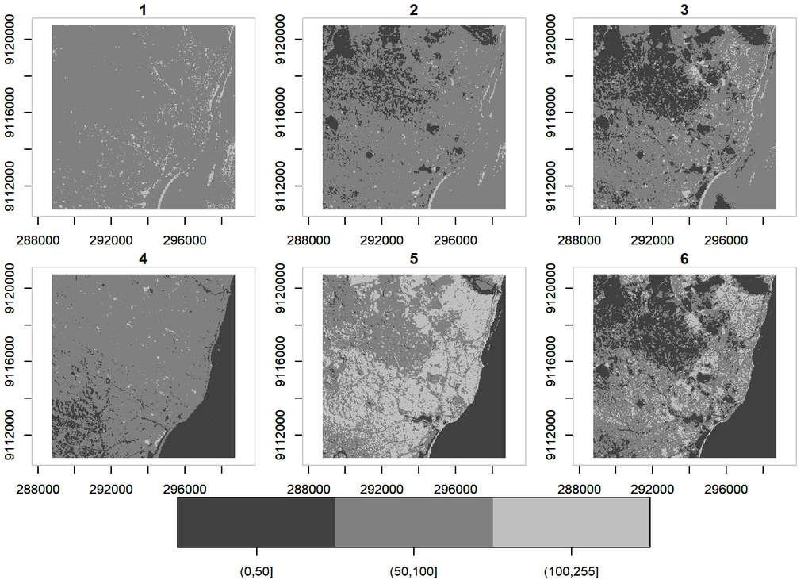

```r
img_corte3 <- cut(img, c(0, 50, 100, 255))

plot(img_corte3, axes =T )
```

Outra função interessante é *dplyr::slice()*, que também permite extrair por exemplo, bandas ou valores determinados de cada dimensão.

Primeiro exemplo, extração das bandas 1 a 3.

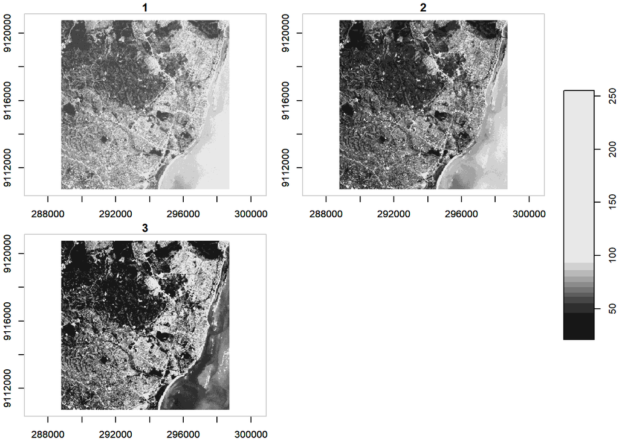

```r
img_s1  <-   img %>% dplyr::slice("band", 1:3)

plot(img_s1, axes = T)
```

Segundo exemplo, extração das colunas 50 a 100, linhas 20 a 60 das bandas 4 a 6 (infravermelho).

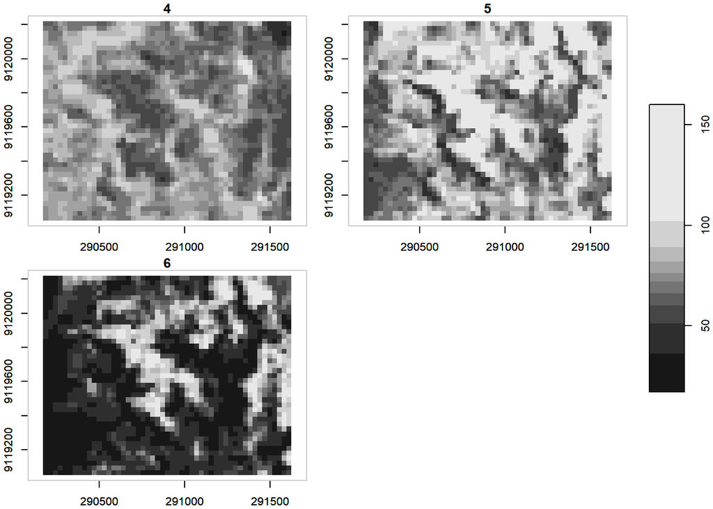

```r
img_s2 <- img        %>%
   dplyr::slice("x", 50:100) %>%
   dplyr::slice("y", 20:60)  %>%
   dplyr::slice("band", 4:6)

plot(img_s2, axes = T)
```

### Referências

**STARS**

stars: Spatiotemporal Arrays, Raster and Vector Data Cubes en:

https://r-spatial.github.io/stars/index.html

https://github.com/r-spatial/stars/

**SIMPLE FEATURES - SF**

Pebesma, E., 2018. Simple Features for R: Standardized Support for Spatial Vector Data. The R Journal 10 (1), 439-446, https://doi.org/10.32614/RJ-2018-009 https://r-spatial.github.io/sf/

Subiza Pina, W.H., 2019 Introdução ao Análise Espacial, IBGE, Rio de Janeiro em https://github.com/HumbertoSubiza/Intro_analise_espacial_R

Versión 1 de 2020-12-11 - Año Covid